# AI Regulation, An Overview

XLVI Annual Seminar, Mississippi Bankruptcy Conference

Artur Pericles L. Monteiro, LL.B, Ph.D.

Mississippi Christian University School of Law

November 20, 2026

# The EU AI Act

*Why?*

## “The Brussels Effect” (Bradford 2020)

- EU as a unilateral global regulator, esp. for tech (Bradford 2023)
- *De facto* Brussels effect (~ California effect)
  - Companies adopt EU rules outside EU
- *De jure* Brussels effect
  - Other countries adopt EU-style rules
- Chief example: GDPR

+ EU influences thinking of scholars, policymakers

[figure not shown]

[figure not shown]

## The Debate Over Claude’s Watermark

[video not shown]

[*This Week in Tech*, August 23, 2026](https://twit.tv/shows/this-week-in-tech/episodes/1098) · 13 seconds

## Why Claude’s Watermark Went Worldwide

[figure not shown]

[Lucas Ropek, *TechCrunch*, August 12, 2026](https://techcrunch.com/2026/08/12/some-claude-users-are-mad-that-anthropics-new-watermarks-will-catch-them-cheating-at-their-jobs-classes/)

EU law requires machine-readable marking of covered AI-generated text. **Anthropic applied the watermark worldwide** because it lacked a reliable way to limit it by region.

## The EU AI Act: “Risk-Based” Tiers

Increasing risk

| tier | scope | obligations |
| --- | --- | --- |
| Unacceptable practices (or risk) | subliminal manipulation,[^1] social scoring,[^2] criminal risk prediction,[^3] and emotion recognition in education and the workplace, among others[^4] | ban |
| High-risk | currently regulated sectors & designated domains (by the Act[^5] or Commission determination) *e.g. education, law enforcement, and biometrics* | Chapter III duties |
| “Limited risk”[^6] | providers of chatbots, synthetic content (watermarking); deployers of emotion recognition systems, “deep fakes” | disclosure |
| Minimal risk |  | voluntary commitments & codes of conduct |

### Which one is a high-risk AI system?

[figure not shown]

✓

[figure not shown]

✓

**Both can qualify as high-risk.**

**Toy · Annex I, Section A**  
AI Act high-risk duties can apply directly.

**Shuttle · Annex I, Section B**  
Safety requirements work through vehicle type approval.

Courtesy of Professor Sofia Ranchórdas.

## The EU AI Act: High-Risk Systems

#### Chapter III Duties (Summary)

- Risk assessment and mitigation
  - known or reasonably foreseeable risks posed by *intended use* to “health, safety or fundamental rights”
- Data governance measures
  - data quality and integrity requirements (incl. bias)
- Documentation and logs
- Transparency, interpretability and “effective human oversight”
- Accuracy, robustness and cybersecurity

Most duties fall on providers[^7]; deployers[^8] have narrower obligations[^9]

#### Chapter III Enforcement and Specification Loopholes (Summary)

- Pre-market risk assessment exemptions from high-risk system duties with imprecise language and far reach[^10]
- Data governance obligations still require specification
- Obligations will be measured against standards created by private standard-setting bodies[^11]
- Conformity assessment, self- or (optional) third-party-conducted
- Much still unknown and left for implementation
  - EU executive agency (AI Office, within European Commission) and Member-State agencies
  - EU-wide board, advisory forum, and scientific panel

See (Wachter 2024).

## Which One Is a High-Risk AI System?

Increasing risk

Assume ordinary consumer chat.

[figure not shown]

×

[figure not shown]

×

[figure not shown]

×

[figure not shown]

×

**None per se.**

**Change the intended use.** A system designed to rank job applicants falls within Annex III.

## The EU AI Act: General-Purpose Models

The final AI Act added a classification for general-purpose models in response to genAI.

| Model classification | Provider obligations |
| --- | --- |
| General-purpose models | Documentation and transparency[^12]; copyright compliance policy |
| Models **with systemic risk**[^13] | Model evaluations incl. red teaming; risk assessment and mitigation; documentation; cybersecurity |

**Systemic-risk presumption:** 10<sup>25</sup> FLOPs in training; authorities may designate other models

**Overlap:** may also qualify as high-risk AI systems[^14]

**Oversight:** AI Office; codes of practice (providers) and “harmonized standards”

#### Standards as *De Facto* Law

> As soon as the joint technical committee of CEN/CENELEC finishes developing its AI Act standards, that document will probably become the de facto legal regime (Kaminski and Selbst 2025).

# The Regulatory Landscape in the U.S.

## The Federal Level

### Congress through 2024

In 2023, senators heard testimony and convened nine AI Insight Forums.

In May 2024, four senators released a bipartisan roadmap for legislation.

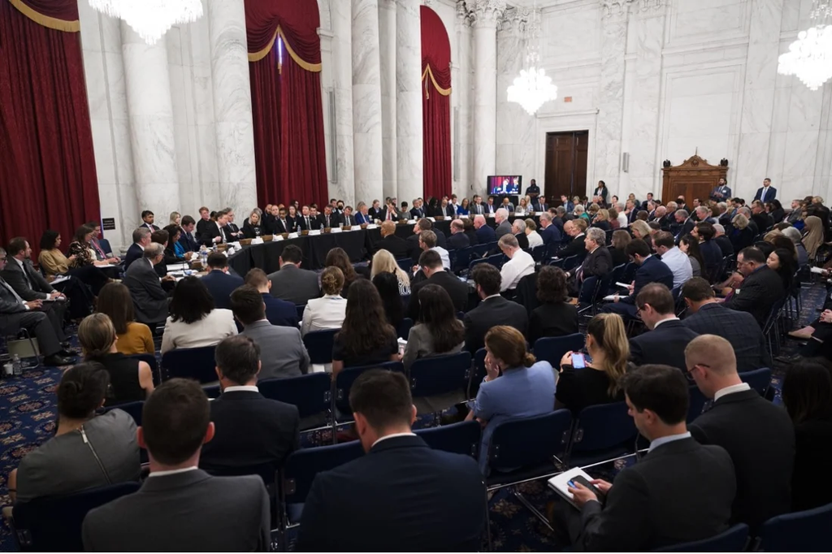

First Senate AI Insight Forum · September 13, 2023

### The TAKE IT DOWN Act

The 2025 law criminalizes certain disclosures of intimate images without consent, including AI-generated deepfakes.

Covered platforms have **48 hours** to remove an image after a valid request.

[figure not shown]

White House Rose Garden · May 19, 2025

### Congress under Trump

The Senate stripped a proposed moratorium on state AI regulation from the 2025 budget bill.

Broader proposals followed in 2026. Congress has yet to enact a comprehensive AI statute.

**99–1**Senate vote to strike the provision  
July 1, 2025

### The Biden White House

**EO 14110.** Agencies designated Chief AI Officers. The order directed safety reporting for covered models under the Defense Production Act.

Developers separately made voluntary commitments on testing, cybersecurity, and transparency.

[figure not shown]

Signing of EO 14110 · October 30, 2023

### The Trump White House

Trump rescinded EO 14110. Revised guidance retained agency Chief AI Officers.

**EO 14365** directed challenges to state AI laws.

In 2026, developers agreed to voluntary internal reviews and external audits.

[figure not shown]

White House AI Summit · July 23, 2025

### Anthropic and two federal interventions

#### Defense procurement

In February 2026, the Department of War demanded access for “all lawful uses.” Anthropic maintained limits on mass domestic surveillance and fully autonomous weapons.

In March, the department designated Anthropic a **supply-chain risk** under 10 U.S.C. § 3252 and 41 U.S.C. § 4713. The challenges produced different rulings.

#### Commerce export controls

In June, Commerce used the Export Control Reform Act to impose **export licensing** for Mythos 5 and Fable 5. Anthropic responded by suspending access for all users.

After the controls were lifted, Fable returned to general availability. Mythos remained limited to trusted partners.

### NIST across three administrations

**2019 · Trump.** A federal plan for developing AI technical standards.

**2023 · Biden.** NIST releases its voluntary AI Risk Management Framework.

**2025–26 · Trump.** The AI Action Plan calls for revising the framework to remove references to misinformation, DEI, and climate change.

Choi’s critique: the framework leaves many requirements open to interpretation.

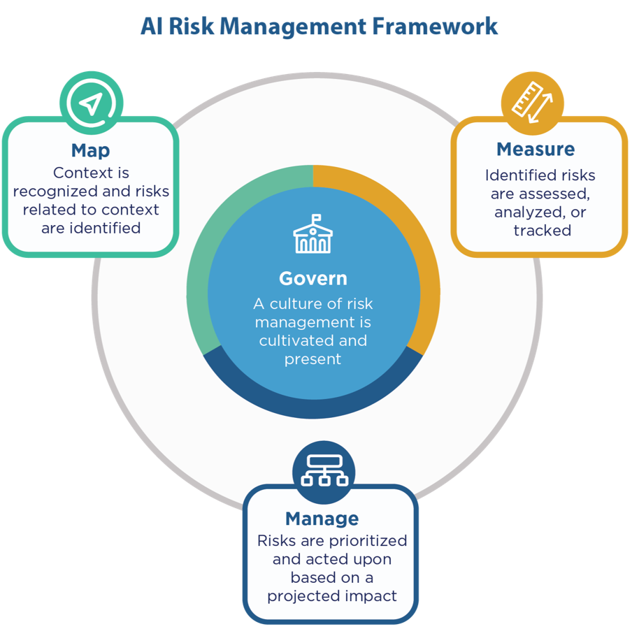

The four functions of the NIST AI RMF

## States

#### Frontier AI Regulation

| Enacted protections | CA | NY | CT |
| --- | --- | --- | --- |
| Report critical safety incidents | ✓ | ✓ | — |
| Publish safety frameworks | ✓ | ✓ | — |
| Protect whistleblowers | ✓ | ✓* | ✓ |

New York’s RAISE duties begin Jan. 1, 2027. Its whistleblower protection comes from Labor Law § 740.

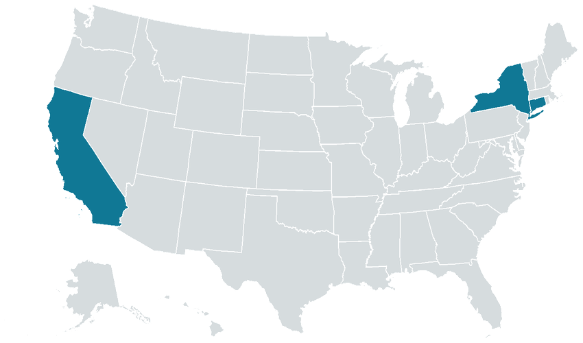

#### AI Companion Regulation

| Enacted safeguards | States in survey |
| --- | --- |
| Identify the bot as AI | All 12 |
| Establish crisis protocols | All 12 |
| Add safeguards for minors | 10 of 12 (except NY and RI) |

Effective dates vary across the twelve states.

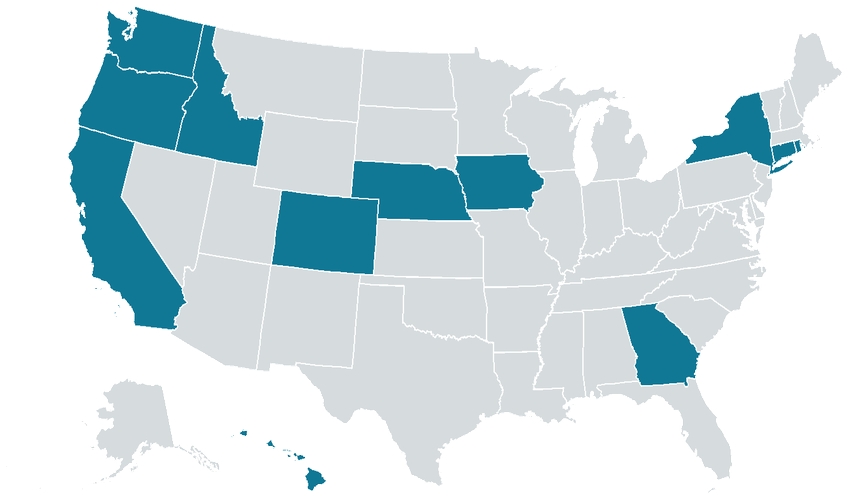

CA · CO · CT · GA · HI · IA · ID · NE · NY · OR · RI · WA

#### Executive Order 14365 and State AI Laws

“Minimally burdensome national policy framework for AI”

- The Justice Department’s AI Litigation Task Force challenges state AI laws.
- The order directs agencies to examine conditions on federal grants to states.

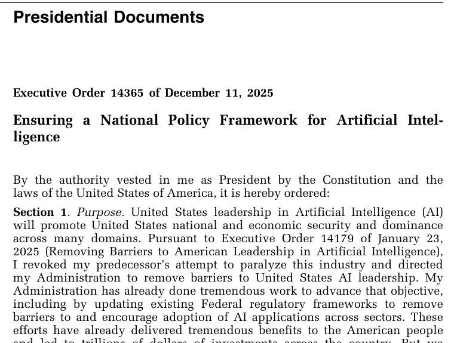

Sources: Rubenstein (2025), Tobey et al. (2026), Brennen (2026)

## States: Rates and Consumer Protection

#### Data Center Regulation (Utility Rates)

- **Separate tariffs for large users:** MD, MN, OR, TX (2025); OK (2026)
- **Cost allocation:** OK requires users to cover their share, including costs left by early departure
- **Beyond rates:** contract review (AL), cooling-water limits (ID), narrower tax breaks (WA, ME)

#### Consumer Protection (Esp. Dynamic Pricing)

- **Personalized pricing:** NY disclosures; CT retail restrictions from July 2027
- **Coordinated rent-setting:** CA, NY restrict pricing algorithms that facilitate coordination
- **Emergency surge pricing:** NE limits ride-hailing dynamic pricing
- **Health insurance:** IA, WA restrict AI use in coverage decisions

Sources: Rubenstein (2025), Tobey et al. (2026), Brennen (2026)

## Other Proposals: A FINRA-Like “Hybrid”?

**Federal supervisor**

Public oversight + ultimate veto

↓

Google

June 2026 proposal

proposes →

**FARO**

Frontier AI regulatory organization

Industry-funded · independent & industry directors

↓

**Frontier AI developers**

Standards · safety frameworks · independent audits

Private expertise and funding + public authority

Sources: Google (2026); Thomas (2026)

## What Regulates What? *Lessig (2006)*

[figure not shown]

[figure not shown]

Lessig: “code,” not just law, “regulates” behavior → law should take advantage of code for more efficient regulation

## What Regulates What? *Winner (1986)*

[figure not shown]

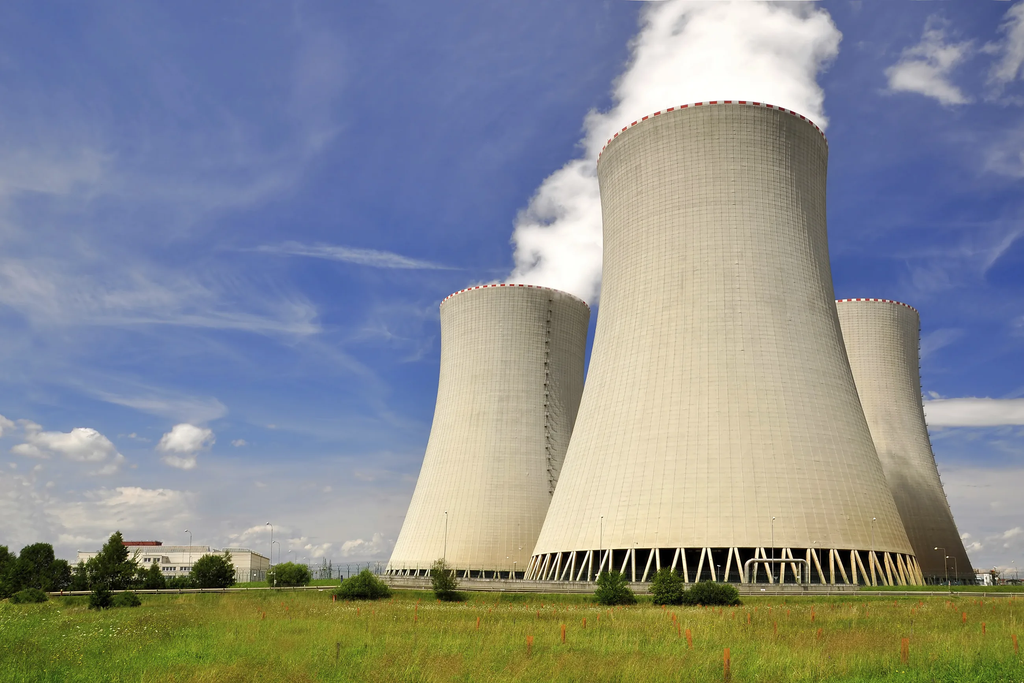

Lessig

[figure not shown]

Winner

[figure not shown]

Winner[^15]: Certain technologies require or are “strongly compatible with” certain political arrangements—ex: nuclear energy and strict control.

# Thanks! 💭? 🗯️?

✉️ amonteiro@mc.edu

🔗 arturpericles.art

# References

Bradford, Anu. 2020. *The Brussels Effect: How the European Union Rules the World*. Oxford University Press. https://doi.org/10.1093/oso/9780190088583.001.0001.

Bradford, Anu. 2023. *Digital Empires: The Global Battle to Regulate Technology*. Oxford University Press. https://doi.org/10.1093/oso/9780197649268.001.0001.

Brennen, Scott Babwah. 2026. “Where State AI Legislation Stands Half Way Into 2026.” *Tech Policy Press*, July 6. https://www.techpolicy.press/where-state-ai-legislation-stands-half-way-into-2026/.

Google. 2026. *A Pragmatic Approach to AI Governance in America*. https://publicpolicy.google/resources/a-pragmatic-approach-to-ai-governance-in-america.pdf.

Kaminski, Margot E., and Andrew D. Selbst. 2025. “An American’s Guide to the EU AI Act.” *Berkeley Technology Law Journal* 40: 1081–133. https://doi.org/10.15779/Z38JS9HB12.

Lessig, Lawrence. 2006. *Code*. 2nd ed. Basic Books.

Rubenstein, David. 2025. “Federalism & Algorithms.” *Arizona Law Review* 67: 979–1058.

Thomas, Mark. 2026. “Designing a FINRA for Frontier AI.” *Lawfare*, July 30. https://www.lawfaremedia.org/article/designing-a-finra-for-frontier-ai.

Tobey, Danny, Ashley Carr, and Michael Atleson. 2026. “What 12 State ‘Companion Bot’ Laws Demand of AI Providers.” *Tech Policy Press*, September 1. https://www.techpolicy.press/what-12-state-companion-bot-laws-demand-of-ai-providers/.

Wachter, Sandra. 2024. “Limitations and Loopholes in the EU AI Act and AI Liability Directives: What This Means for the European Union, the United States, and Beyond.” *Yale Journal of Law & Technology* 26 (3): 671.

Winner, Langdon. 1986. “Do Artefacts Have Politics?” In *The Whale and the Reactor: A Search for Limits in an Age of High Technology*, by Langdon Winner. The University of Chicago Press.

## Footnotes

[^1]: Art. 5(1)(a): “an AI system that deploys subliminal techniques beyond a person’s consciousness or purposefully manipulative or deceptive techniques, with the objective, or the effect of materially distorting the behaviour of a person or a group of persons by appreciably impairing their ability to make an informed decision, thereby causing them to take a decision that they would not have otherwise taken in a manner that causes or is reasonably likely to cause that person, another person or group of persons significant harm;”
[^2]: Art. 5(1)(c):

    > AI systems for the evaluation or classification of natural persons or groups of persons over a certain period of time based on their social behaviour or known, inferred or predicted personal or personality characteristics, with the social score leading to either or both of the following:  
    > (i) detrimental or unfavourable treatment of certain natural persons or groups of persons in social contexts that are unrelated to the contexts in which the data was originally generated or collected;  
    > (ii) detrimental or unfavourable treatment of certain natural persons or groups of persons that is unjustified or disproportionate to their social behaviour or its gravity;
[^3]: But note the scope of the prohibition. Art. 5(1)(d): “making risk assessments of natural persons in order to assess or predict the risk of a natural person committing a criminal offence, *based solely on the profiling of a natural person or on assessing their personality traits and characteristics*; this prohibition shall not apply to AI systems used to support the human assessment of the involvement of a person in a criminal activity, which is already based on objective and verifiable facts directly linked to a criminal activity.”
[^4]: See [Article 5](https://eur-lex.europa.eu/eli/reg/2024/1689/oj/eng#cpt_III).
[^5]: In broad strokes:
    1. Biometrics;
    2. Critical infrastructure;
    3. Education and vocational training;
    4. Employment, workers’ management and access to self-employment;
    5. Essential private services and essential public services and benefits;
    6. Law enforcement;
    7. Migration, asylum and border control management;
    8. Court system and elections.

    See [Annex III](https://eur-lex.europa.eu/eli/reg/2024/1689/oj/eng#anx_III) for definitions and exemptions.
[^6]: See [Art. 50](https://eur-lex.europa.eu/eli/reg/2024/1689/oj/eng#art_50).
[^7]: Typically the developer; also encompasses anyone who “places it on the market or puts the AI system into service under its own name or trademark.” See Art. 3(3).
[^8]: Anyone “using an AI system under its authority,” except “in the course of a personal non-professional activity.” See Art. 3(4)
[^9]: See [Art. 26](https://eur-lex.europa.eu/eli/reg/2024/1689/oj/eng#art_26).
[^10]: Cf. art. 6(3): “perform narrow procedural task”; “improve the result of a previously completed human activity”; “perform a preparatory task”; “detect decision-making patterns or deviations from prior decision-making patterns and is not meant to replace or influence the previously completed human assessment, without proper human review”.
[^11]: European Committee for Standardization (CEN) and European Committee for Electrotechnical Standardization (CENELEC).
[^12]: Open-source models are exempted.
[^13]: ‘[S]ystemic risk’ means a risk that is specific to the high-impact capabilities of general-purpose AI models, having a significant impact on the Union market due to their reach, or due to actual or reasonably foreseeable negative effects on public health, safety, public security, fundamental rights, or the society as a whole, that can be propagated at scale across the value chain.
[^14]: Recital 85.
[^15]: Often remembered for example of politics through technology in Robert Moses’ low overpasses thought to be deliberately excluding. (On the specific example, [see](https://www.bloomberg.com/news/articles/2017-07-09/robert-moses-and-his-racist-parkway-explained).)